# Part II - Loan Data from Prosper

## by Abiola Ogunbajo

## Investigation Overview

The overall goals of this presentation is to highlight:

1. The highest length of loans in months.
2. The most selected listing category.
3. The effect of the borrower's verifiable income on the loan status.
4. The interaction between the monthly loan payment, loan original amount by term of loans.

#### Key Insights

Many borrowers select 'debt consolidation' as the listing category and take loans for 36 months. Whether the borrower's income is verifiable or not does not affect the loan status. There was an interesting interaction among the monthly loan payment, loan original amount and term of loans. There is a higher positive correlation between monthly loan payment and loan original amount in borrowers with 12 months as the term of loans compared to borrowers with 36 and 60 months as the term of loans.

The visualizations in the explanatory presentation are:

1. The count of the length of loans.
2. The most selected listing category by the borrowers.
3. The effect of the borrower's verifiable income on the loan status.
4. The interaction between the monthly loan payment, loan original amount by term of loans.

## Dataset Overview

The Loan Data from Prosper dataset is a financial dataset which is related to the loan, borrowers, interest rates, etc. Prosper or Prosper Marketplace Inc. is a San Francisco, California based company specializing in loans at low interest rates to the borrowers. We are using the dataset from Prosper for exploratory data analysis.The dataset from prosper is comprised of 81 variables and contains 113937 entries. I selected 15 variables out of the initial 81 variables for visualization. They are: LoanKey, Term, LoanStatus, BorrowerAPR, BorrowerRate, ListingCategory (numeric), EmploymentStatus, IsBorrowerHomeowner, DebtToIncomeRatio, IncomeRange, IncomeVerifiable, StatedMonthlyIncome, LoanOriginalAmount, MonthlyLoanPayment, Investors.

#### Assessing Data

After assesing the dataset for visualization, there were duplicate rows, complex column names and non-descriptive listing categories.

#### Cleaning Data

The duplicate rows were dropped using pandas' drop_duplicates method, the column names were renamed with more suitable names using pandas' rename function and the non-descriptive listing categories were replaced with a descriptive listing categories using .replace() method.

The main features of interest in this dataset are Borrower APR, Borrower Rate, Term, Loan Status, Loan Original Amount, Stated Monthly Income and Monthly Loan Payment.The features in the dataset that will support an investigation into the features of interest are Listing Category, Employment Status, Is Borrower A Home Owner?, Debt to Income Ratio, Income Verifiable and Investors.

## (Visualization 1)

#### What is the highest length of loans in months?

The bar plot below shows that most loans are given out for a length of 36 months(3 years), followed by 60 months (5 years) and less loans are given out for a length of 12 months (1 year).

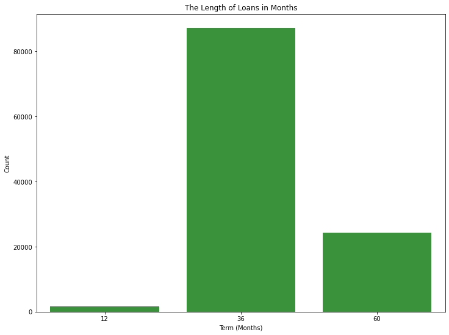

## (Visualization 2)

#### What is the highest category of listing selected by the borrower?

The plot below shows that most loans are obtained for the purpose of debt consolidation.

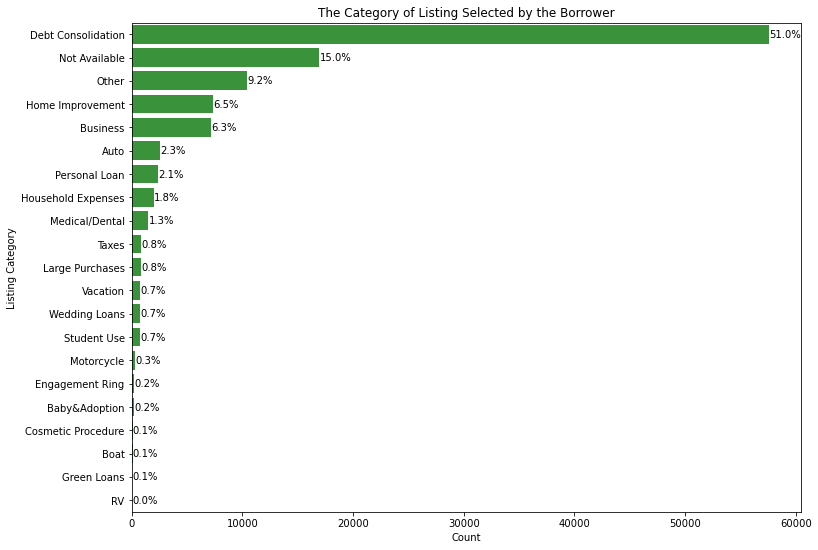

## (Visualization 3)

#### Does the borrower's verifiable income have any effect on the loan status?

The plot below shows that most of the borrowers that have completed, current, defaulted and chargedoff loans have verifiable income. Whether the borrowers' income is verifiable or not does not have a major effect on the loan status.

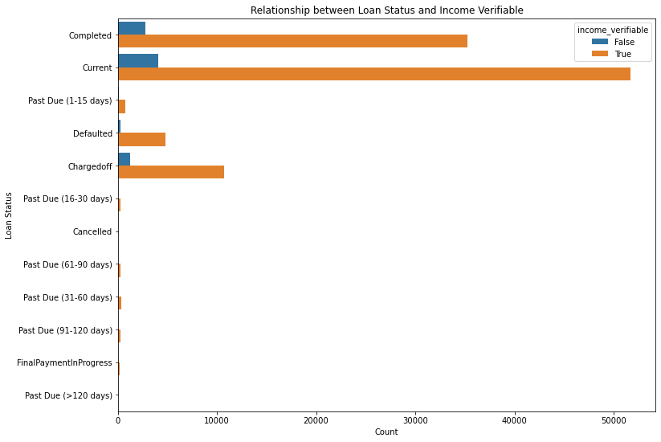

## (Visualization 4)

#### What is the relationship between monthly loan payment and loan original amount by term of loans?

The plot below shows that there is a higher positive correlation between monthly loan payment and loan original amount in borrowers with 12 months as the term of loans compared to borrowers with 36 and 60 months as the term of loans.

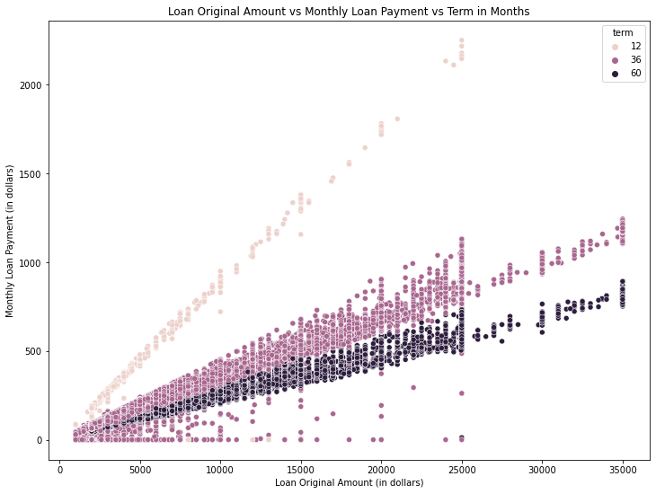